# HW6: The Gender Wage Gap by Age, Occupation and Education

Piter Miedema

2026-10-09

```r
library(ggplot2)
library(tidyverse)
library(haven)
library(viridis)
library(knitr)
library(car)
load("~/Downloads/acs2021_recoded.RData")
dim(acs2021)
```

```
## [1] 3252599     112
```

## Data and sample

For this study, we will look at working age people (25 to 64), who are in the labor force, worked 48+ weeks, usually work 35+ hours per week and have an income.

```r
acs_work <- acs2021 %>%
  filter(AGE >= 25, AGE <= 64,     # working age
         LABFORCE == 2,            # in the labor force
         WKSWORK2 >= 5,            # worked 48+ weeks last year
         UHRSWORK >= 35,           # usually works 35+ hours a week
         INCWAGE > 0)              # has wage income

nrow(acs_work)
```

```
## [1] 881444
```

```r
rm(acs2021)   # drop the big dataset to free up memory
gc()
```

```
##            used  (Mb) gc trigger   (Mb) limit (Mb)  max used   (Mb)
## Ncells  1307137  69.9    2270131  121.3         NA   2270131  121.3
## Vcells 74580827 569.1  311926059 2379.9      16384 352540382 2689.7
```

Next, we will separate people into 3 educational categories: Advanced degree, College, Less than college.

```r
acs_work <- acs_work %>%
  mutate(
    sex = factor(ifelse(female == 1, "Women", "Men"), levels = c("Men", "Women")),
    educ_group = case_when(
      educ_advdeg  == 1 ~ "Advanced degree",
      educ_college == 1 ~ "College",
      TRUE              ~ "Less than college"),
    educ_group = factor(educ_group,
                        levels = c("Less than college", "College", "Advanced degree"))
  )

table(acs_work$SEX)                        # check: only Male and Female
```

```
##
##   Male Female
## 487309 394135
```

```r
table(acs_work$educ_group, acs_work$sex)   # how many people in each cell
```

```
##
##                        Men  Women
##   Less than college 280527 196161
##   College           126261 112751
##   Advanced degree    80521  85223
```

Next, we’ll identify specific jobs. One glitch, people in the Management, Business & Financial group all list OCC = NA, so this will be one large job category. I chose the 21 largest occupation categories because I wanted physicians to be included.

```r
# Missing OCC = Management, Business & Financial (codes 0010-0960 are unlabeled in this file)
acs_work <- acs_work %>%
  mutate(occ = ifelse(is.na(OCC), "Management & Business", as.character(OCC)))

# The 21 most common occupations in the sample
top21 <- acs_work %>%
  count(occ, sort = TRUE) %>%
  head(21)
kable(top21)
```

| occ | n |
| --- | --- |
| Management & Business | 196487 |
| Registered nurses | 21890 |
| Elementary and middle school teachers | 20018 |
| Driver/sales workers and truck drivers | 19899 |
| First-Line supervisors of retail sales workers | 17376 |
| Software developers | 15019 |
| Customer service representatives | 14177 |
| Secretaries and administrative assistants, except legal, medical, and executive | 13609 |
| Laborers and freight, stock, and material movers, hand | 10872 |
| Janitors and building cleaners | 10160 |
| Retail salespersons | 9838 |
| Secondary school teachers | 9769 |
| Lawyers | 9277 |
| Postsecondary teachers | 8787 |
| Sales representatives, wholesale and manufacturing | 8495 |
| First-Line supervisors of office and administrative support workers | 8218 |
| Other production workers | 7987 |
| First-Line supervisors of non-retail sales workers | 7091 |
| Bookkeeping, accounting, and auditing clerks | 6934 |
| Construction laborers | 6850 |
| Other physicians | 6676 |

```r
# Keep those 21, put everyone else in "Other", and shorten the long names for graphs
acs_work <- acs_work %>%
  mutate(profession = ifelse(occ %in% top21$occ, occ, "Other"),
         profession = dplyr::recode(profession,
                             "Driver/sales workers and truck drivers" = "Truck drivers",
                             "First-Line supervisors of retail sales workers" = "Retail sales supervisors",
                             "Secretaries and administrative assistants, except legal, medical, and executive" = "Secretaries & admin assistants",
                             "Laborers and freight, stock, and material movers, hand" = "Laborers & material movers",
                             "Sales representatives, wholesale and manufacturing" = "Sales reps, wholesale & mfg",
                             "First-Line supervisors of office and administrative support workers" = "Office & admin supervisors",
                             "First-Line supervisors of non-retail sales workers" = "Non-retail sales supervisors",
                             "Bookkeeping, accounting, and auditing clerks" = "Bookkeeping clerks",
                             "Other physicians" = "Physicians",
                             "Elementary and middle school teachers" = "Elementary & middle school teachers",
                             "Janitors and building cleaners" = "Janitors & building cleaners"))

table(acs_work$profession)
```

```
##
##                  Bookkeeping clerks               Construction laborers
##                                6934                                6850
##    Customer service representatives Elementary & middle school teachers
##                               14177                               20018
##        Janitors & building cleaners          Laborers & material movers
##                               10160                               10872
##                             Lawyers               Management & Business
##                                9277                              196487
##        Non-retail sales supervisors          Office & admin supervisors
##                                7091                                8218
##                               Other            Other production workers
##                              452015                                7987
##                          Physicians              Postsecondary teachers
##                                6676                                8787
##                   Registered nurses            Retail sales supervisors
##                               21890                               17376
##                 Retail salespersons         Sales reps, wholesale & mfg
##                                9838                                8495
##           Secondary school teachers      Secretaries & admin assistants
##                                9769                               13609
##                 Software developers                       Truck drivers
##                               15019                               19899
```

## Raw wage gap by occupation and education

What follows is the raw wage gap by profession and education. Groups with <1000 were left out (janitors with advanced degrees, for example).

```r
# Gap for each profession (all education levels together)
gap_prof <- acs_work %>%
  filter(profession != "Other") %>%
  group_by(profession) %>%
  summarize(n_men     = sum(sex == "Men"),
            n_women   = sum(sex == "Women"),
            avg_men   = mean(INCWAGE[sex == "Men"]),
            avg_women = mean(INCWAGE[sex == "Women"]),
            ratio     = avg_women / avg_men) %>%
  arrange(ratio)

kable(gap_prof, digits = 2, format.args = list(big.mark = ","),
      caption = "Average wage by sex and profession (ratio = women / men)")
```

Average wage by sex and profession (ratio = women / men)

| profession | n_men | n_women | avg_men | avg_women | ratio |
| --- | --- | --- | --- | --- | --- |
| Retail salespersons | 6,124 | 3,714 | 68,141.88 | 45,069.31 | 0.66 |
| Retail sales supervisors | 9,820 | 7,556 | 74,318.18 | 52,077.83 | 0.70 |
| Management & Business | 104,610 | 91,877 | 127,399.44 | 90,081.01 | 0.71 |
| Customer service representatives | 4,535 | 9,642 | 62,153.30 | 44,402.15 | 0.71 |
| Janitors & building cleaners | 7,169 | 2,991 | 40,305.24 | 28,832.44 | 0.72 |
| Other production workers | 5,745 | 2,242 | 50,844.87 | 37,767.13 | 0.74 |
| Secretaries & admin assistants | 903 | 12,706 | 59,819.71 | 45,612.22 | 0.76 |
| Physicians | 3,990 | 2,686 | 293,793.18 | 225,486.41 | 0.77 |
| Lawyers | 5,279 | 3,998 | 210,658.61 | 162,343.97 | 0.77 |
| Office & admin supervisors | 2,635 | 5,583 | 74,850.25 | 57,694.29 | 0.77 |
| Truck drivers | 18,910 | 989 | 55,296.99 | 43,060.16 | 0.78 |
| Laborers & material movers | 8,516 | 2,356 | 42,814.34 | 33,854.24 | 0.79 |
| Construction laborers | 6,597 | 253 | 47,528.58 | 38,226.48 | 0.80 |
| Postsecondary teachers | 4,424 | 4,363 | 98,295.21 | 80,185.84 | 0.82 |
| Bookkeeping clerks | 917 | 6,017 | 57,742.97 | 47,742.23 | 0.83 |
| Software developers | 12,394 | 2,625 | 149,764.14 | 126,559.54 | 0.85 |
| Sales reps, wholesale & mfg | 6,154 | 2,341 | 101,923.07 | 88,008.16 | 0.86 |
| Non-retail sales supervisors | 4,587 | 2,504 | 99,287.27 | 86,899.78 | 0.88 |
| Registered nurses | 2,828 | 19,062 | 86,519.34 | 76,938.78 | 0.89 |
| Elementary & middle school teachers | 3,976 | 16,042 | 64,680.21 | 59,032.59 | 0.91 |
| Secondary school teachers | 4,164 | 5,605 | 67,477.64 | 63,011.49 | 0.93 |

```r
# Same thing split by education, keeping only groups with 1000+ men AND 1000+ women
gap_prof_educ <- acs_work %>%
  filter(profession != "Other") %>%
  group_by(profession, educ_group) %>%
  summarize(n_men     = sum(sex == "Men"),
            n_women   = sum(sex == "Women"),
            avg_men   = mean(INCWAGE[sex == "Men"]),
            avg_women = mean(INCWAGE[sex == "Women"]),
            ratio     = avg_women / avg_men,
            .groups = "drop") %>%
  filter(n_men >= 1000, n_women >= 1000)

kable(gap_prof_educ, digits = 2, format.args = list(big.mark = ","),
      caption = "Average wage by sex, profession and education (groups with 1000+ of each sex)")
```

Average wage by sex, profession and education (groups with 1000+ of each sex)

| profession | educ_group | n_men | n_women | avg_men | avg_women | ratio |
| --- | --- | --- | --- | --- | --- | --- |
| Customer service representatives | Less than college | 2,779 | 7,096 | 50,209.61 | 39,857.75 | 0.79 |
| Customer service representatives | College | 1,429 | 2,090 | 76,209.94 | 56,156.99 | 0.74 |
| Elementary & middle school teachers | College | 1,737 | 6,702 | 56,991.08 | 51,588.23 | 0.91 |
| Elementary & middle school teachers | Advanced degree | 2,135 | 8,814 | 71,918.08 | 66,109.63 | 0.92 |
| Janitors & building cleaners | Less than college | 6,716 | 2,858 | 39,938.38 | 28,646.45 | 0.72 |
| Laborers & material movers | Less than college | 7,864 | 2,163 | 42,492.46 | 32,837.40 | 0.77 |
| Lawyers | Advanced degree | 4,897 | 3,592 | 213,156.14 | 167,077.48 | 0.78 |
| Management & Business | Less than college | 36,264 | 31,084 | 88,734.59 | 64,141.32 | 0.72 |
| Management & Business | College | 42,816 | 37,425 | 134,020.03 | 94,381.81 | 0.70 |
| Management & Business | Advanced degree | 25,530 | 23,368 | 171,217.50 | 117,697.93 | 0.69 |
| Non-retail sales supervisors | Less than college | 2,568 | 1,229 | 75,871.35 | 64,407.65 | 0.85 |
| Office & admin supervisors | Less than college | 1,534 | 3,597 | 62,558.60 | 51,808.09 | 0.83 |
| Other production workers | Less than college | 5,261 | 2,030 | 49,485.76 | 36,712.41 | 0.74 |
| Physicians | Advanced degree | 3,990 | 2,686 | 293,793.18 | 225,486.41 | 0.77 |
| Postsecondary teachers | Advanced degree | 3,620 | 3,587 | 104,908.56 | 84,820.24 | 0.81 |
| Registered nurses | College | 1,573 | 10,014 | 88,169.93 | 79,295.16 | 0.90 |
| Retail sales supervisors | Less than college | 6,918 | 5,679 | 64,906.42 | 44,202.35 | 0.68 |
| Retail sales supervisors | College | 2,336 | 1,481 | 90,803.00 | 72,189.13 | 0.80 |
| Retail salespersons | Less than college | 4,358 | 2,753 | 58,017.73 | 38,167.02 | 0.66 |
| Sales reps, wholesale & mfg | Less than college | 3,008 | 1,112 | 75,927.69 | 60,271.94 | 0.79 |
| Secondary school teachers | College | 1,673 | 1,955 | 59,398.21 | 53,917.54 | 0.91 |
| Secondary school teachers | Advanced degree | 2,377 | 3,529 | 73,785.70 | 68,502.41 | 0.93 |
| Software developers | College | 6,616 | 1,255 | 142,711.00 | 119,432.51 | 0.84 |
| Software developers | Advanced degree | 4,148 | 1,098 | 172,371.77 | 141,613.57 | 0.82 |

It appears that across professions and accounting for educational level there exists a raw wage gap. The gap is smallest among teachers (both elementary and HS) and nurses, where women make >90% of what men make, and greatest among retail salespeople with less than college (66%), retail sales supervisors (68%) and all management and business professions at all educational levels (69% to 72%). Janitors and cleaners with less than college also comes in at 72%. In general, education doesn’t narrow the raw gap significantly except in the case of retail sales supervisors, where women with less than college make 68% of men, while women with a college degree make 80% as much.

## Wage gap by age

Next, we’ll look at wage gap by age.

```r
acs_work <- acs_work %>%
  mutate(sector = case_when(
    profession %in% c("Management & Business", "Lawyers", "Physicians", "Software developers",
                      "Postsecondary teachers", "Registered nurses",
                      "Elementary & middle school teachers", "Secondary school teachers") ~ "Professional",
    profession %in% c("Retail salespersons", "Retail sales supervisors", "Non-retail sales supervisors",
                      "Sales reps, wholesale & mfg", "Customer service representatives",
                      "Secretaries & admin assistants", "Office & admin supervisors",
                      "Bookkeeping clerks") ~ "Sales & Office",
    profession %in% c("Truck drivers", "Laborers & material movers", "Janitors & building cleaners",
                      "Construction laborers", "Other production workers") ~ "Manual",
    TRUE ~ "Other"))

table(acs_work$sector, acs_work$sex)
```

```
##
##                     Men  Women
##   Manual          46937   8831
##   Other          263032 188983
##   Professional   141665 146258
##   Sales & Office  35675  50063
```

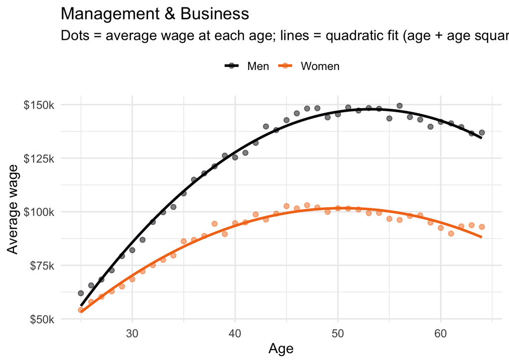

```r
by_age_prof <- acs_work %>%
  filter(profession != "Other") %>%
  group_by(profession, sex, AGE) %>%
  summarize(avg_wage = mean(INCWAGE), .groups = "drop")

plot_prof <- function(which_prof) {
  ggplot(filter(by_age_prof, profession == which_prof),
         aes(x = AGE, y = avg_wage, color = sex)) +
    geom_point(size = 2, alpha = 0.5) +
    geom_smooth(method = "lm", formula = y ~ x + I(x^2), se = FALSE, linewidth = 1.2) +
    scale_color_viridis_d(option = "inferno", end = 0.7) +
    scale_y_continuous(labels = scales::label_dollar(scale = 1/1000, suffix = "k")) +
    labs(x = "Age", y = "Average wage", color = NULL,
         title = which_prof,
         subtitle = "Dots = average wage at each age; lines = quadratic fit (age + age squared)") +
    theme_minimal(base_size = 14) +
    theme(legend.position = "top")
}
plot_prof("Management & Business")
```

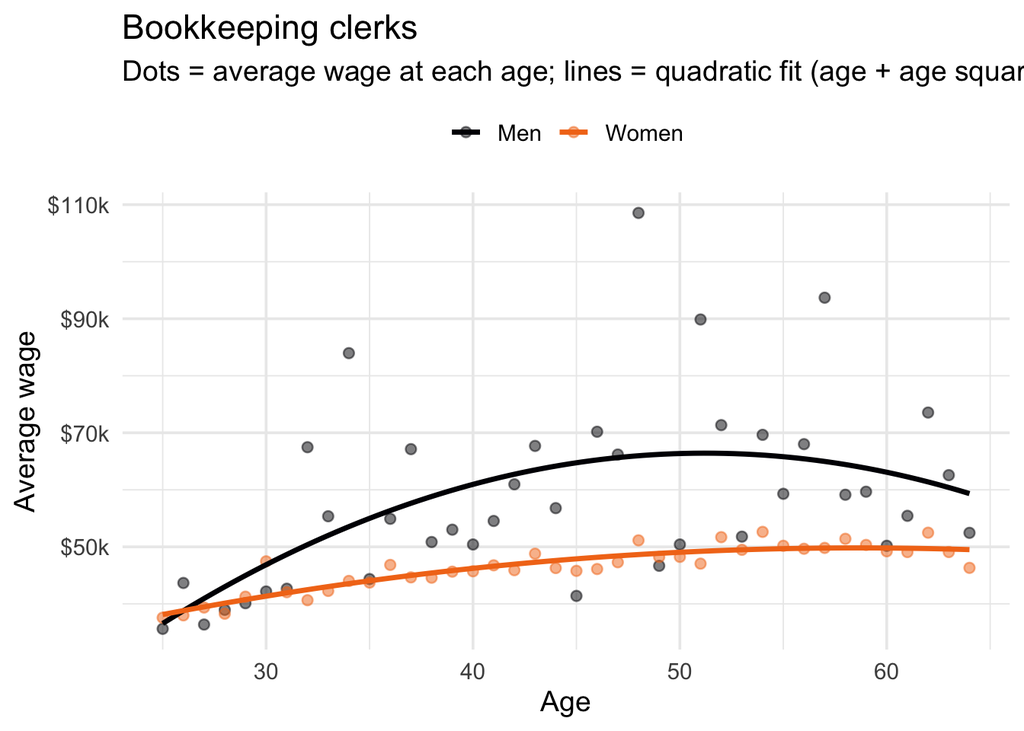

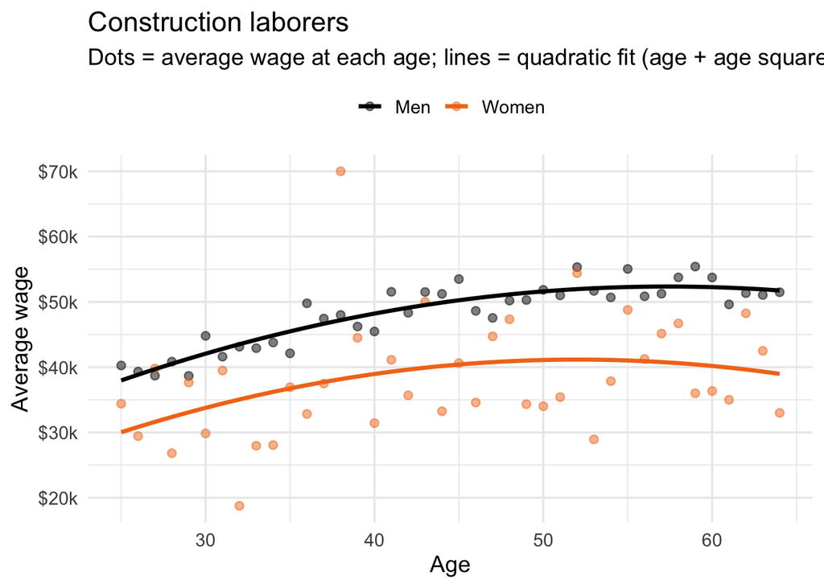

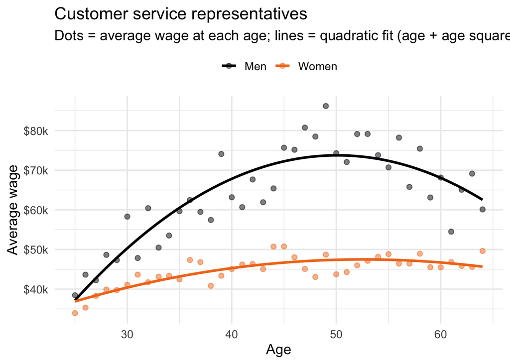

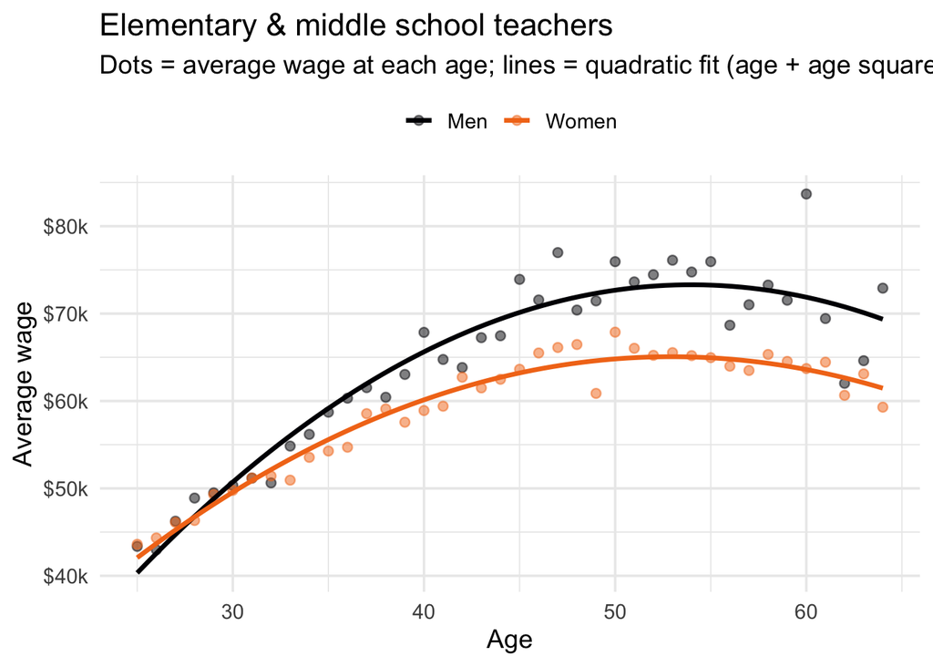

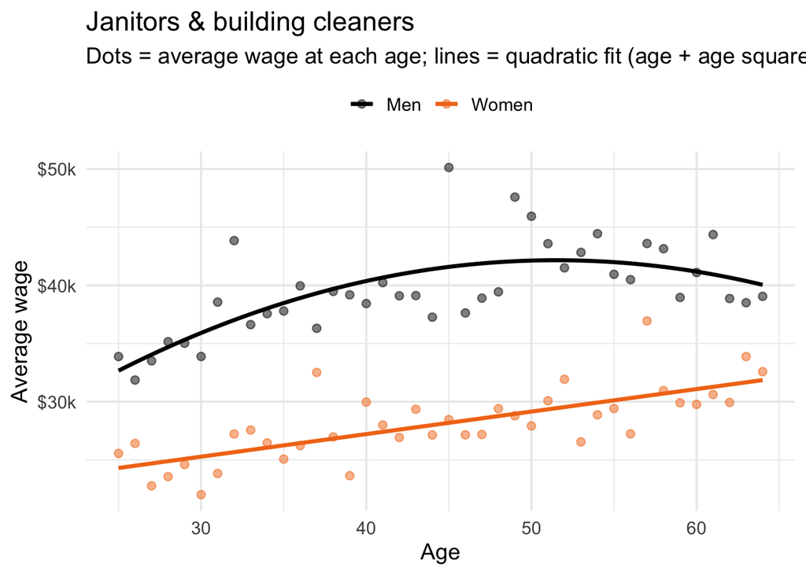

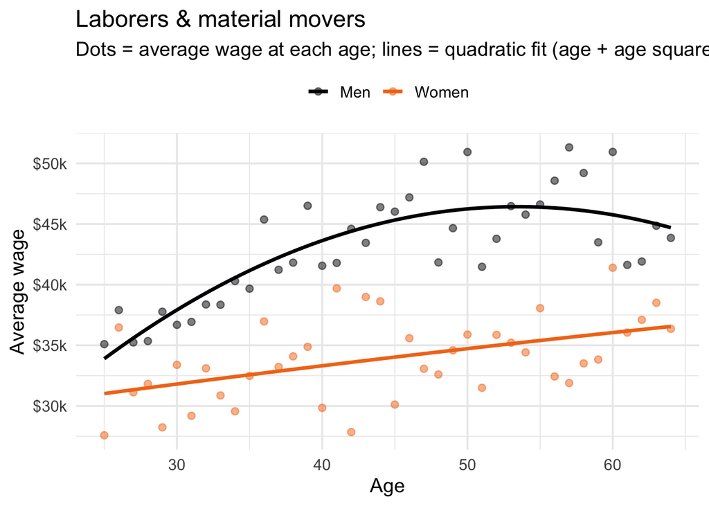

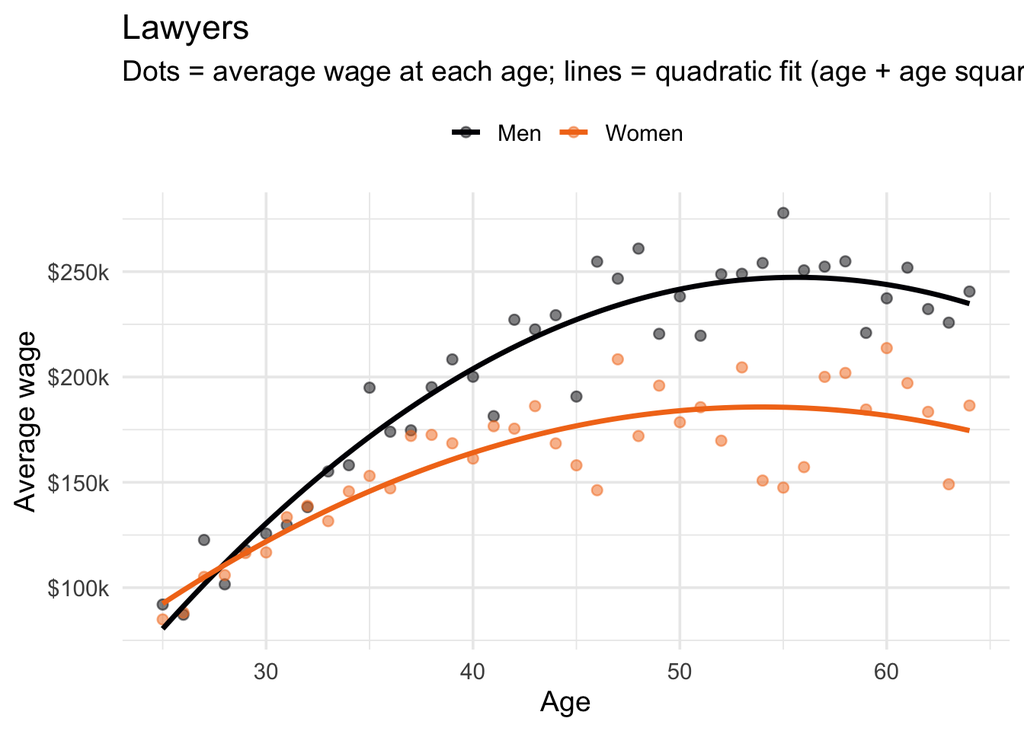

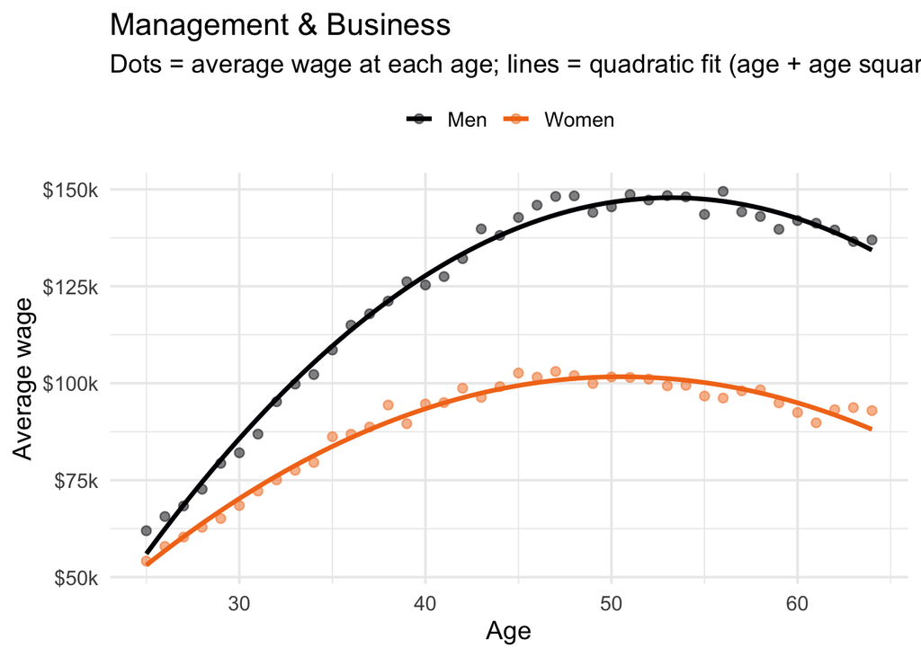

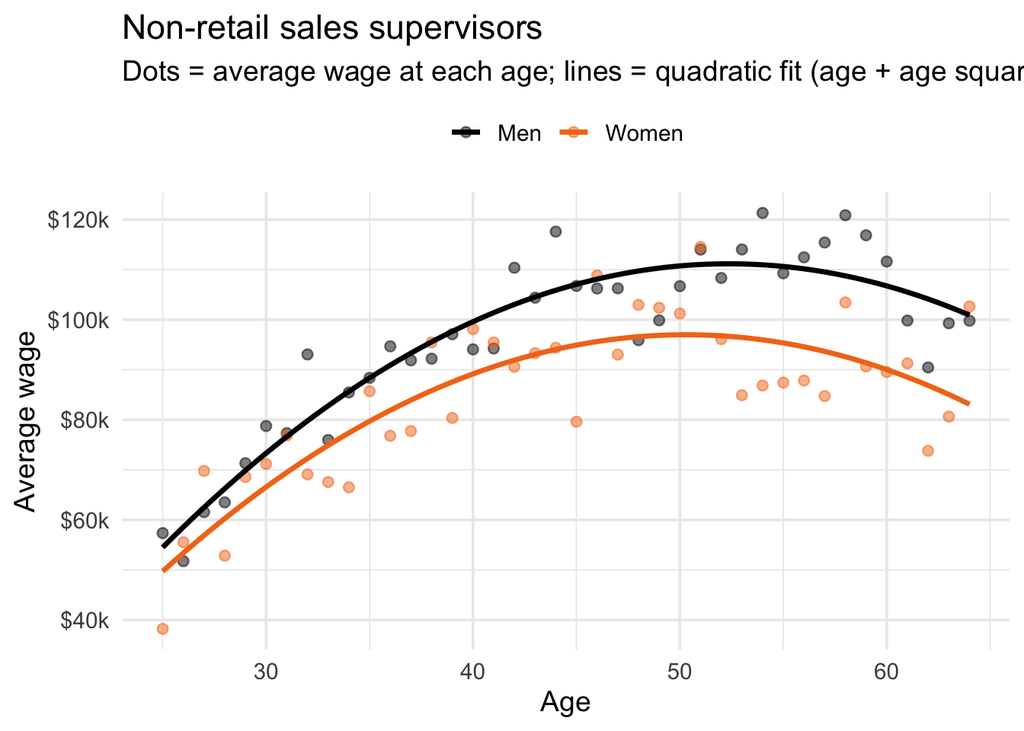

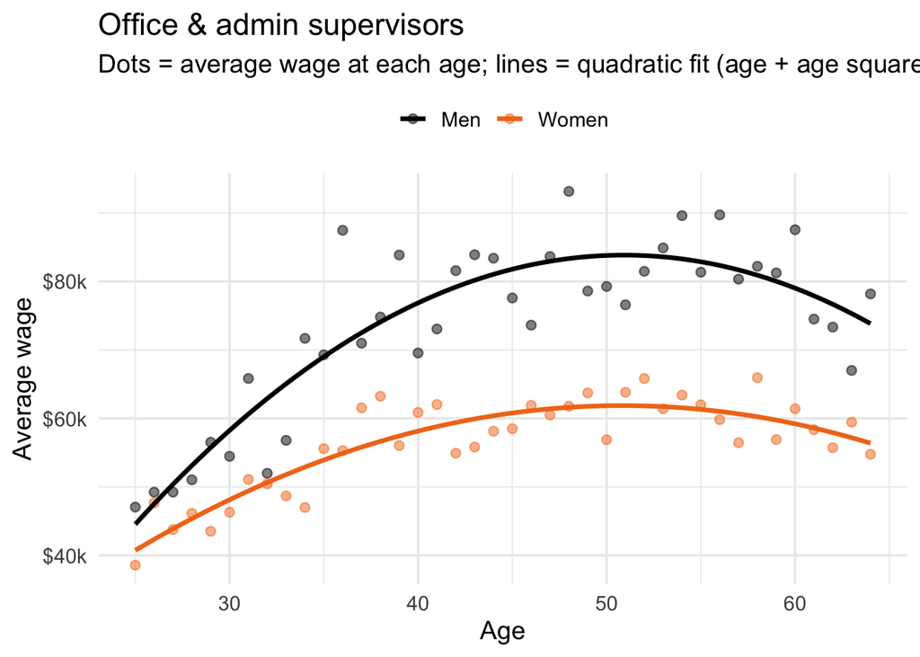

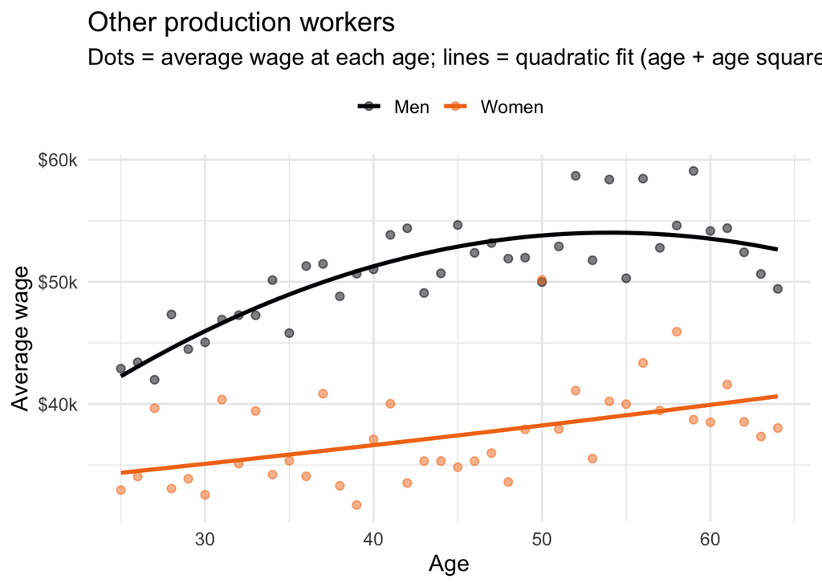

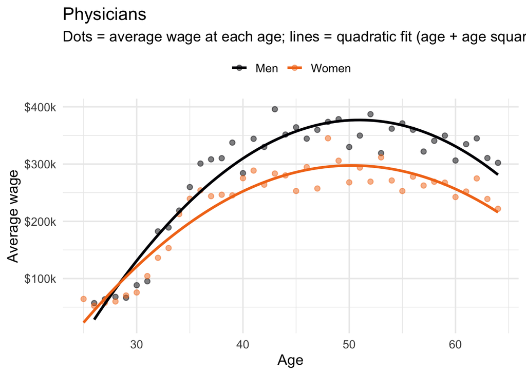

[9 more figures not shown]

```r
for (p in sort(unique(by_age_prof$profession))) {
  print(plot_prof(p))
}
```

The age profiles show two distinct patterns. In lower-wage manual and clerical jobs (truck drivers, janitors, production workers, retail salespersons, secretaries), women earn 20–30% less than men already at ages 25–29, and the gap stays roughly the same over the career. In professional and supervisory jobs, men and women start at nearly equal pay: female lawyers, physicians, and software developers earn 94–96% of what men earn in their late 20s. But the gap opens up in the 30s, and by ages 40–49 women in these jobs earn only about 78–80% of what men earn. The timing coincides with the typical age of having children, which is consistent with a “motherhood penalty”. Teachers and nurses, where pay is set largely by salary scales, show small and stable gaps throughout.

Note: this is a single cross-section, so differences across ages also reflect cohort differences (women aged 45 in 2021 started their careers under different conditions than women aged 27), not only how individual careers evolve.

## Age, Age² and higher-order terms

Next, a regression of wage on age, age squared, sex, education and occupation.

```r
acs_work$profession <- relevel(factor(acs_work$profession), ref = "Other")

model1 <- lm(INCWAGE ~ AGE + I(AGE^2) + female + educ_college + educ_advdeg + profession,
             data = acs_work)
summary(model1)
```

```
##
## Call:
## lm(formula = INCWAGE ~ AGE + I(AGE^2) + female + educ_college +
##     educ_advdeg + profession, data = acs_work)
##
## Residuals:
##     Min      1Q  Median      3Q     Max
## -284100  -30033   -8858   14036  725470
##
## Coefficients:
##                                                 Estimate Std. Error  t value
## (Intercept)                                   -6.588e+04  1.215e+03  -54.210
## AGE                                            5.064e+03  5.705e+01   88.758
## I(AGE^2)                                      -4.702e+01  6.391e-01  -73.564
## female                                        -2.482e+04  1.525e+02 -162.731
## educ_college                                   3.331e+04  1.813e+02  183.691
## educ_advdeg                                    5.650e+04  2.177e+02  259.517
## professionBookkeeping clerks                   2.191e+02  8.248e+02    0.266
## professionConstruction laborers               -1.268e+04  8.293e+02  -15.286
## professionCustomer service representatives    -3.145e+03  5.803e+02   -5.420
## professionElementary & middle school teachers -2.486e+04  5.043e+02  -49.301
## professionJanitors & building cleaners        -2.106e+04  6.829e+02  -30.837
## professionLaborers & material movers          -1.599e+04  6.606e+02  -24.206
## professionLawyers                              8.519e+04  7.294e+02  116.797
## professionManagement & Business                3.262e+04  1.900e+02  171.740
## professionNon-retail sales supervisors         2.353e+04  8.123e+02   28.960
## professionOffice & admin supervisors           3.195e+03  7.564e+02    4.224
## professionOther production workers            -9.369e+03  7.672e+02  -12.211
## professionPhysicians                           1.590e+05  8.548e+02  186.035
## professionPostsecondary teachers              -1.073e+04  7.446e+02  -14.415
## professionRegistered nurses                    1.466e+04  4.776e+02   30.702
## professionRetail sales supervisors             5.074e+03  5.248e+02    9.668
## professionRetail salespersons                 -8.573e+02  6.917e+02   -1.239
## professionSales reps, wholesale & mfg          2.383e+04  7.442e+02   32.020
## professionSecondary school teachers           -2.771e+04  7.032e+02  -39.404
## professionSecretaries & admin assistants      -3.232e+03  5.964e+02   -5.418
## professionSoftware developers                  5.553e+04  5.702e+02   97.385
## professionTruck drivers                       -8.743e+03  4.969e+02  -17.596
##                                               Pr(>|t|)
## (Intercept)                                    < 2e-16 ***
```

[output cut: 17 more lines]

```
## professionPostsecondary teachers               < 2e-16 ***
## professionRegistered nurses                    < 2e-16 ***
## professionRetail sales supervisors             < 2e-16 ***
## professionRetail salespersons                    0.215
## professionSales reps, wholesale & mfg          < 2e-16 ***
## professionSecondary school teachers            < 2e-16 ***
## professionSecretaries & admin assistants      6.01e-08 ***
## professionSoftware developers                  < 2e-16 ***
## professionTruck drivers                        < 2e-16 ***
## ---
## Signif. codes:  0 '***' 0.001 '**' 0.01 '*' 0.05 '.' 0.1 ' ' 1
##
## Residual standard error: 67830 on 881417 degrees of freedom
## Multiple R-squared:  0.2524, Adjusted R-squared:  0.2523
## F-statistic: 1.144e+04 on 26 and 881417 DF,  p-value: < 2.2e-16
```

```r
b <- coef(model1)
peak_age <- -b["AGE"] / (2 * b["I(AGE^2)"])
peak_age
```

```
##      AGE
## 53.85066
```

Next, we’ll test whether higher order age terms add information.

```r
model2 <- lm(INCWAGE ~ AGE + I(AGE^2) + I(AGE^3) + I(AGE^4) +
               female + educ_college + educ_advdeg + profession,
             data = acs_work)
summary(model2)$coefficients[1:5, ]
```

```
##                  Estimate   Std. Error   t value     Pr(>|t|)
## (Intercept)  2.215364e+05 2.076799e+04  10.66721 1.454626e-26
## AGE         -2.283445e+04 2.024092e+03 -11.28133 1.630369e-29
## I(AGE^2)     9.350749e+02 7.188777e+01  13.00743 1.119331e-38
## I(AGE^3)    -1.489906e+01 1.104541e+00 -13.48892 1.834867e-41
## I(AGE^4)     8.243565e-02 6.207626e-03  13.27974 3.061700e-40
```

```r
# Joint F-test: are AGE^3 and AGE^4 both zero?
linearHypothesis(model2, c("I(AGE^3) = 0", "I(AGE^4) = 0"))
```

```
##
## Linear hypothesis test:
## I(AGE^3) = 0
## I(AGE^4) = 0
##
## Model 1: restricted model
## Model 2: INCWAGE ~ AGE + I(AGE^2) + I(AGE^3) + I(AGE^4) + female + educ_college +
##     educ_advdeg + profession
##
##   Res.Df        RSS Df  Sum of Sq     F    Pr(>F)
## 1 881417 4.0558e+15
## 2 881415 4.0549e+15  2 8.8762e+11 96.47 < 2.2e-16 ***
## ---
## Signif. codes:  0 '***' 0.001 '**' 0.01 '*' 0.05 '.' 0.1 ' ' 1
```

```r
# Same test a second way: compare the two models directly
anova(model1, model2)
```

```
## Analysis of Variance Table
##
## Model 1: INCWAGE ~ AGE + I(AGE^2) + female + educ_college + educ_advdeg +
##     profession
## Model 2: INCWAGE ~ AGE + I(AGE^2) + I(AGE^3) + I(AGE^4) + female + educ_college +
##     educ_advdeg + profession
##   Res.Df        RSS Df  Sum of Sq     F    Pr(>F)
## 1 881417 4.0558e+15
## 2 881415 4.0549e+15  2 8.8762e+11 96.47 < 2.2e-16 ***
## ---
## Signif. codes:  0 '***' 0.001 '**' 0.01 '*' 0.05 '.' 0.1 ' ' 1
```

```r
# Does it improve the fit much?
c(R2_quadratic = summary(model1)$r.squared, R2_quartic = summary(model2)$r.squared)
```

```
## R2_quadratic   R2_quartic
##    0.2523650    0.2525286
```

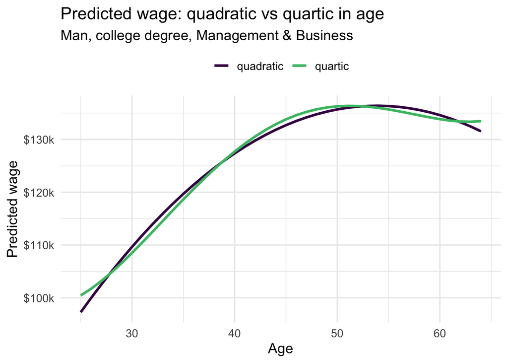

```r
# Predicted wage by age from both models, for one example person:
# a man with a college degree in Management & Business
pred_data <- data.frame(AGE = 25:64, female = 0, educ_college = 1, educ_advdeg = 0,
                        profession = "Management & Business")
pred_data$quadratic <- predict(model1, pred_data)
pred_data$quartic   <- predict(model2, pred_data)

pred_data %>%
  pivot_longer(c(quadratic, quartic), names_to = "model", values_to = "pred") %>%
  ggplot(aes(x = AGE, y = pred, color = model)) +
  geom_line(linewidth = 1.2) +
  scale_color_viridis_d(end = 0.7) +
  scale_y_continuous(labels = scales::label_dollar(scale = 1/1000, suffix = "k")) +
  labs(x = "Age", y = "Predicted wage", color = NULL,
       title = "Predicted wage: quadratic vs quartic in age",
       subtitle = "Man, college degree, Management & Business") +
  theme_minimal(base_size = 14) + theme(legend.position = "top")
```

```r
pred_data$AGE[which.max(pred_data$quartic)]   # peak age in the quartic model
```

```
## [1] 51
```

AGE³ and AGE⁴ are jointly statistically significant (F = 96.5, p < 0.001), but R² goes up by only 0.0002 and the predicted curves are nearly identical. With 881,000 observations even tiny differences are significant, so the quadratic is good enough.

## log(Age)

Next we’ll try log(Age) instead of a polynomial.

```r
# (a) log(Age) alone
model3 <- lm(INCWAGE ~ log(AGE) + female + educ_college + educ_advdeg + profession,
             data = acs_work)
summary(model3)$coefficients[1:3, ]
```

```
##              Estimate Std. Error    t value Pr(>|t|)
## (Intercept) -89695.59  1043.7944  -85.93224        0
## log(AGE)     39857.24   275.0649  144.90121        0
## female      -24920.90   152.7974 -163.09764        0
```

```r
# (b) a polynomial in log(Age): log(Age) + log(Age)^2
model4 <- lm(INCWAGE ~ log(AGE) + I(log(AGE)^2) + female + educ_college + educ_advdeg + profession,
             data = acs_work)
summary(model4)$coefficients[1:4, ]
```

```
##                 Estimate Std. Error    t value Pr(>|t|)
## (Intercept)   -889892.31 15268.9936  -58.28101        0
## log(AGE)       473171.67  8253.5996   57.32913        0
## I(log(AGE)^2)  -58338.24  1110.5881  -52.52914        0
## female         -24796.43   152.5773 -162.51719        0
```

```r
# Compare the fit of the three models
c(quadratic_age = summary(model1)$r.squared,
  log_age       = summary(model3)$r.squared,
  log_age_sq    = summary(model4)$r.squared)
```

```
## quadratic_age       log_age    log_age_sq
##     0.2523650     0.2496069     0.2519487
```

```r
# Why polynomials in log(Age) add little: these are almost the same variable
cor(acs_work$AGE, log(acs_work$AGE))
```

```
## [1] 0.9927471
```

```r
cor(log(acs_work$AGE), log(acs_work$AGE)^2)
```

```
## [1] 0.9994527
```

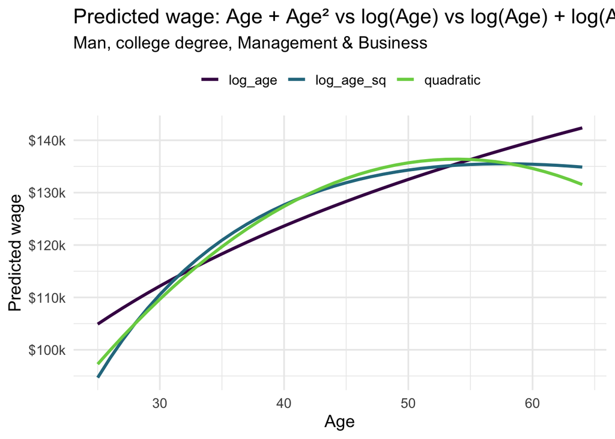

```r
pred_data$log_age    <- predict(model3, pred_data)
pred_data$log_age_sq <- predict(model4, pred_data)

pred_data %>%
  pivot_longer(c(quadratic, log_age, log_age_sq), names_to = "model", values_to = "pred") %>%
  ggplot(aes(x = AGE, y = pred, color = model)) +
  geom_line(linewidth = 1.2) +
  scale_color_viridis_d(end = 0.8) +
  scale_y_continuous(labels = scales::label_dollar(scale = 1/1000, suffix = "k")) +
  labs(x = "Age", y = "Predicted wage", color = NULL,
       title = "Predicted wage: Age + Age² vs log(Age) vs log(Age) + log(Age)²",
       subtitle = "Man, college degree, Management & Business") +
  theme_minimal(base_size = 14) + theme(legend.position = "top")
```

log(Age) captures the idea that wages grow fast early in a career and then level off, using a single coefficient. But it cannot capture the decline in wages after the early 50s, so it fits worse than Age + Age². Adding log(Age)² restores the hump, but over ages 25–64 log(Age) is nearly linear in Age, so this just reproduces the quadratic in a less interpretable form.

## Children and the wage gap

Next, we’ll look into the “motherhood penalty.” Only ages 25 to 45 are included as that is most likely when a mother would have a child in the household. This regression compares mothers and non-mothers at the same age and education level by occupation.

```r
# has_child = 1 if the person has at least one of their own children living at home
acs_work <- acs_work %>%
  mutate(has_child = as.numeric(NCHILD > 0))

# Ages 25-45 only: older parents' children have often moved out
acs_young <- acs_work %>% filter(AGE <= 45)

# Average wage for the four groups
acs_young %>%
  group_by(sex, has_child) %>%
  summarize(n = n(), avg_wage = mean(INCWAGE), .groups = "drop") %>%
  kable(digits = 0, format.args = list(big.mark = ","))
```

| sex | has_child | n | avg_wage |
| --- | --- | --- | --- |
| Men | 0 | 129,170 | 67,618 |
| Men | 1 | 131,038 | 89,882 |
| Women | 0 | 95,292 | 61,521 |
| Women | 1 | 111,286 | 65,164 |

```r
# Raw averages: women with vs. without children, ages 25-45
kids_prof <- acs_young %>%
  filter(profession != "Other") %>%
  group_by(profession) %>%
  summarize(n_mothers        = sum(sex == "Women" & has_child == 1),
            n_women_nokids   = sum(sex == "Women" & has_child == 0),
            avg_mothers      = mean(INCWAGE[sex == "Women" & has_child == 1]),
            avg_women_nokids = mean(INCWAGE[sex == "Women" & has_child == 0]),
            ratio_women      = avg_mothers / avg_women_nokids,
            ratio_men        = mean(INCWAGE[sex == "Men" & has_child == 1]) /
              mean(INCWAGE[sex == "Men" & has_child == 0])) %>%
  arrange(ratio_women)

kable(kids_prof, digits = 2, format.args = list(big.mark = ","),
      caption = "Raw: wage with kids / wage without kids, ages 25-45")
```

Raw: wage with kids / wage without kids, ages 25-45

| profession | n_mothers | n_women_nokids | avg_mothers | avg_women_nokids | ratio_women | ratio_men |
| --- | --- | --- | --- | --- | --- | --- |
| Construction laborers | 84 | 54 | 35,082.14 | 39,429.63 | 0.89 | 1.16 |
| Other production workers | 589 | 438 | 34,197.11 | 37,308.68 | 0.92 | 1.20 |
| Laborers & material movers | 648 | 488 | 31,596.30 | 33,859.02 | 0.93 | 1.18 |
| Truck drivers | 267 | 253 | 38,829.59 | 40,511.46 | 0.96 | 1.19 |
| Secretaries & admin assistants | 2,840 | 1,850 | 42,198.03 | 42,882.86 | 0.98 | 1.11 |
| Bookkeeping clerks | 1,187 | 858 | 44,012.64 | 44,232.63 | 1.00 | 1.22 |
| Registered nurses | 6,061 | 4,243 | 71,416.81 | 71,298.73 | 1.00 | 1.11 |
| Customer service representatives | 2,760 | 2,424 | 42,840.14 | 42,430.87 | 1.01 | 1.42 |
| Office & admin supervisors | 1,430 | 984 | 54,344.97 | 52,988.31 | 1.03 | 1.31 |
| Janitors & building cleaners | 679 | 390 | 26,926.36 | 26,217.97 | 1.03 | 1.21 |
| Software developers | 836 | 918 | 128,317.34 | 124,861.87 | 1.03 | 1.17 |
| Retail sales supervisors | 2,263 | 1,983 | 51,824.27 | 49,911.25 | 1.04 | 1.42 |
| Elementary & middle school teachers | 5,717 | 3,505 | 56,351.67 | 52,282.41 | 1.08 | 1.13 |
| Secondary school teachers | 1,867 | 1,298 | 61,109.53 | 56,646.15 | 1.08 | 1.11 |
| Retail salespersons | 857 | 1,012 | 45,993.23 | 41,208.10 | 1.12 | 1.47 |
| Management & Business | 25,655 | 22,594 | 87,550.24 | 77,512.51 | 1.13 | 1.37 |
| Non-retail sales supervisors | 729 | 521 | 83,447.60 | 73,645.87 | 1.13 | 1.25 |
| Sales reps, wholesale & mfg | 621 | 542 | 87,489.69 | 77,024.91 | 1.14 | 1.32 |
| Lawyers | 1,192 | 1,232 | 168,226.85 | 134,024.11 | 1.26 | 1.38 |
| Postsecondary teachers | 1,085 | 1,173 | 78,141.57 | 59,868.63 | 1.31 | 1.63 |
| Physicians | 850 | 819 | 249,890.94 | 139,492.19 | 1.79 | 1.83 |

```r
# Same comparison, controlling for age and education, run separately for each profession
kids_effect <- acs_young %>%
  filter(profession != "Other") %>%
  group_by(profession) %>%
  group_modify(~ {
    m <- lm(log(INCWAGE) ~ AGE + I(AGE^2) + female + has_child + I(female * has_child) +
              educ_college + educ_advdeg, data = .x)
    b <- coef(m)
    tibble(father_effect = exp(b["has_child"]) - 1,
           mother_effect = exp(b["has_child"] + b["I(female * has_child)"]) - 1)
  }) %>%
  ungroup() %>%
  arrange(mother_effect)

kable(kids_effect, digits = 3,
      caption = "Wage difference from having children, controlling for age and education (log model)")
```

Wage difference from having children, controlling for age and education (log model)

| profession | father_effect | mother_effect |
| --- | --- | --- |
| Construction laborers | 0.108 | -0.160 |
| Software developers | 0.028 | -0.092 |
| Laborers & material movers | 0.148 | -0.056 |
| Secretaries & admin assistants | 0.097 | -0.055 |
| Secondary school teachers | 0.009 | -0.051 |
| Other production workers | 0.178 | -0.049 |
| Registered nurses | 0.059 | -0.046 |
| Bookkeeping clerks | 0.146 | -0.037 |
| Sales reps, wholesale & mfg | 0.130 | -0.028 |
| Elementary & middle school teachers | 0.045 | -0.020 |
| Truck drivers | 0.141 | -0.019 |
| Retail sales supervisors | 0.221 | -0.013 |
| Office & admin supervisors | 0.207 | -0.004 |
| Management & Business | 0.165 | 0.000 |
| Customer service representatives | 0.268 | 0.011 |
| Retail salespersons | 0.263 | 0.022 |
| Janitors & building cleaners | 0.189 | 0.043 |
| Non-retail sales supervisors | 0.176 | 0.049 |
| Postsecondary teachers | 0.270 | 0.056 |
| Lawyers | 0.179 | 0.080 |
| Physicians | 0.308 | 0.147 |

## Dummy variables

Next, some experiments with dummy variables, using only college graduates.

```r
acs_coll <- acs_work %>% filter(educ_college == 1 | educ_advdeg == 1)

coef(lm(INCWAGE ~ AGE + I(AGE^2) + female + educ_hs, data = acs_coll))
```

```
##   (Intercept)           AGE      I(AGE^2)        female       educ_hs
## -102440.25713    9292.83064     -88.36139  -36398.80990            NA
```

```r
coef(lm(INCWAGE ~ AGE + I(AGE^2) + female + educ_college, data = acs_coll))
```

```
##  (Intercept)          AGE     I(AGE^2)       female educ_college
## -58745.21018   8143.60533    -76.41715 -37695.66655 -29017.30212
```

```r
coef(lm(INCWAGE ~ AGE + I(AGE^2) + female + educ_college + educ_advdeg, data = acs_coll))
```

```
##  (Intercept)          AGE     I(AGE^2)       female educ_college  educ_advdeg
## -58745.21018   8143.60533    -76.41715 -37695.66655 -29017.30212           NA
```

```r
coef(lm(INCWAGE ~ AGE + I(AGE^2) + female + I(female^2), data = acs_coll))
```

```
##   (Intercept)           AGE      I(AGE^2)        female   I(female^2)
## -102440.25713    9292.83064     -88.36139  -36398.80990            NA
```

In a sample of only college graduates, educ_hs is 0 for everyone, so it has no variation and R reports NA. With only educ_college in the model, the base group is advanced degree, so its coefficient (−29,017) means BA holders earn about $29,000 less than people with an advanced degree. Putting both educ_college and educ_advdeg in is the dummy variable trap: every person has exactly one of them, so together they duplicate the intercept and R drops one. Squaring a dummy is pointless because 0² = 0 and 1² = 1, so female² is identical to female. Similarly, because the sample is restricted to full-time workers in the labor force, a dummy for being in the labor force would have no variation.

## Log wage model with gender–age interactions

Next, we’ll see if log(INCWAGE) gives a better fit to the data.

```r
model_int <- lm(log(INCWAGE) ~ AGE + I(AGE^2) + female + I(female * AGE) + I(female * AGE^2) +
                  educ_college + educ_advdeg + profession,
                data = acs_work)
summary(model_int)$coefficients[1:6, ]
```

```
##                        Estimate   Std. Error    t value     Pr(>|t|)
## (Intercept)        9.1049534347 1.474844e-02 617.350135 0.000000e+00
## AGE                0.0685183074 6.931191e-04  98.855027 0.000000e+00
## I(AGE^2)          -0.0006516319 7.759780e-06 -83.975565 0.000000e+00
## female             0.2174165767 2.194580e-02   9.906979 3.892893e-23
## I(female * AGE)   -0.0209185919 1.032666e-03 -20.256874 3.241536e-91
## I(female * AGE^2)  0.0002026171 1.157382e-05  17.506501 1.312849e-68
```

```r
# Are the two interaction terms jointly significant?
linearHypothesis(model_int, c("I(female * AGE) = 0", "I(female * AGE^2) = 0"))
```

```
##
## Linear hypothesis test:
## I(female * AGE) = 0
## I(female * AGE^2) = 0
##
## Model 1: restricted model
## Model 2: log(INCWAGE) ~ AGE + I(AGE^2) + female + I(female * AGE) + I(female *
##     AGE^2) + educ_college + educ_advdeg + profession
##
##   Res.Df    RSS Df Sum of Sq      F    Pr(>F)
## 1 881417 331876
## 2 881415 331522  2    353.91 470.47 < 2.2e-16 ***
## ---
## Signif. codes:  0 '***' 0.001 '**' 0.01 '*' 0.05 '.' 0.1 ' ' 1
```

```r
# Peak age for men and for women
bi <- coef(model_int)
peak_men   <- -bi["AGE"] / (2 * bi["I(AGE^2)"])
peak_women <- -(bi["AGE"] + bi["I(female * AGE)"]) /
  (2 * (bi["I(AGE^2)"] + bi["I(female * AGE^2)"]))
c(men = unname(peak_men), women = unname(peak_women))
```

```
##      men    women
## 52.57439 53.00462
```

```r
# Log wage model without interactions (same variables as model1, but log wage)
model_log <- lm(log(INCWAGE) ~ AGE + I(AGE^2) + female + educ_college + educ_advdeg + profession,
                data = acs_work)

# Compare R-squared: dollars vs log vs log with interactions
c(dollar_model     = summary(model1)$r.squared,
  log_model        = summary(model_log)$r.squared,
  log_interactions = summary(model_int)$r.squared)
```

```
##     dollar_model        log_model log_interactions
##        0.2523650        0.3095840        0.3103202
```

```r
# Effects in the log model as percentages
bl <- coef(model_log)
exp(bl[c("female", "educ_college", "educ_advdeg")]) - 1
```

```
##       female educ_college  educ_advdeg
##   -0.2487192    0.5028374    0.8729573
```

The log wage model has a higher R² (0.31 vs 0.25), so it explains more of the variation in wages. In the log model, women earn about 25% less than men with the same age, education and profession. Adding female × Age and female × Age² barely changes R², but the interaction terms are jointly highly significant (F ≈ 470) and change the shape: women’s wages rise more slowly with age, so the gap widens over a career.

Finally, we’ll look at a log wage model with gender-age interactions for each occupation.

```r
# Run the interaction model separately in each profession, and predict wages at every age
pred_all <- acs_work %>%
  filter(profession != "Other") %>%
  group_by(profession) %>%
  group_modify(~ {
    m <- lm(log(INCWAGE) ~ AGE + I(AGE^2) + female + I(female * AGE) + I(female * AGE^2) +
              educ_college + educ_advdeg, data = .x)
    common_educ <- names(which.max(table(.x$educ_group)))   # most common education in this job
    newdata <- expand.grid(AGE = 25:64, female = c(0, 1))
    newdata$educ_college <- as.numeric(common_educ == "College")
    newdata$educ_advdeg  <- as.numeric(common_educ == "Advanced degree")
    newdata$educ_used    <- common_educ
    newdata$pred         <- exp(predict(m, newdata))
    newdata
  }) %>%
  ungroup() %>%
  mutate(sex = ifelse(female == 1, "Women", "Men"))

# Women's predicted wage / men's, at ages 25, 35, 45, 55
ratios <- pred_all %>%
  filter(AGE %in% c(25, 35, 45, 55)) %>%
  select(profession, educ_used, AGE, sex, pred) %>%
  pivot_wider(names_from = sex, values_from = pred) %>%
  mutate(ratio = Women / Men) %>%
  select(profession, educ_used, AGE, ratio) %>%
  pivot_wider(names_from = AGE, names_prefix = "age_", values_from = ratio) %>%
  arrange(age_55)

kable(ratios, digits = 2,
      caption = "Women's predicted wage as a share of men's, by profession and age")
```

Women’s predicted wage as a share of men’s, by profession and age

| profession | educ_used | age_25 | age_35 | age_45 | age_55 |
| --- | --- | --- | --- | --- | --- |
| Retail salespersons | Less than college | 0.85 | 0.73 | 0.67 | 0.65 |
| Retail sales supervisors | Less than college | 0.89 | 0.79 | 0.72 | 0.69 |
| Other production workers | Less than college | 0.80 | 0.73 | 0.71 | 0.72 |
| Management & Business | College | 0.90 | 0.79 | 0.73 | 0.72 |
| Janitors & building cleaners | Less than college | 0.74 | 0.70 | 0.70 | 0.73 |
| Physicians | Advanced degree | 0.98 | 0.90 | 0.83 | 0.75 |
| Customer service representatives | Less than college | 0.94 | 0.80 | 0.75 | 0.76 |
| Office & admin supervisors | Less than college | 0.89 | 0.81 | 0.77 | 0.76 |
| Truck drivers | Less than college | 0.68 | 0.72 | 0.75 | 0.77 |
| Lawyers | Advanced degree | 1.08 | 0.90 | 0.80 | 0.77 |
| Laborers & material movers | Less than college | 0.90 | 0.80 | 0.76 | 0.78 |
| Postsecondary teachers | Advanced degree | 1.08 | 0.94 | 0.85 | 0.79 |
| Secretaries & admin assistants | Less than college | 0.84 | 0.80 | 0.78 | 0.79 |
| Construction laborers | Less than college | 0.85 | 0.74 | 0.73 | 0.81 |
| Software developers | College | 0.98 | 0.86 | 0.81 | 0.83 |
| Sales reps, wholesale & mfg | Less than college | 1.01 | 0.87 | 0.82 | 0.84 |
| Bookkeeping clerks | Less than college | 1.04 | 0.88 | 0.82 | 0.85 |
| Non-retail sales supervisors | Less than college | 0.96 | 0.90 | 0.87 | 0.87 |
| Elementary & middle school teachers | Advanced degree | 0.99 | 0.93 | 0.90 | 0.88 |
| Secondary school teachers | Advanced degree | 0.99 | 0.93 | 0.90 | 0.90 |
| Registered nurses | College | 0.95 | 0.90 | 0.89 | 0.92 |

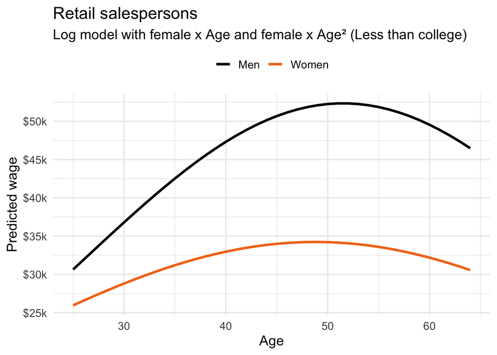

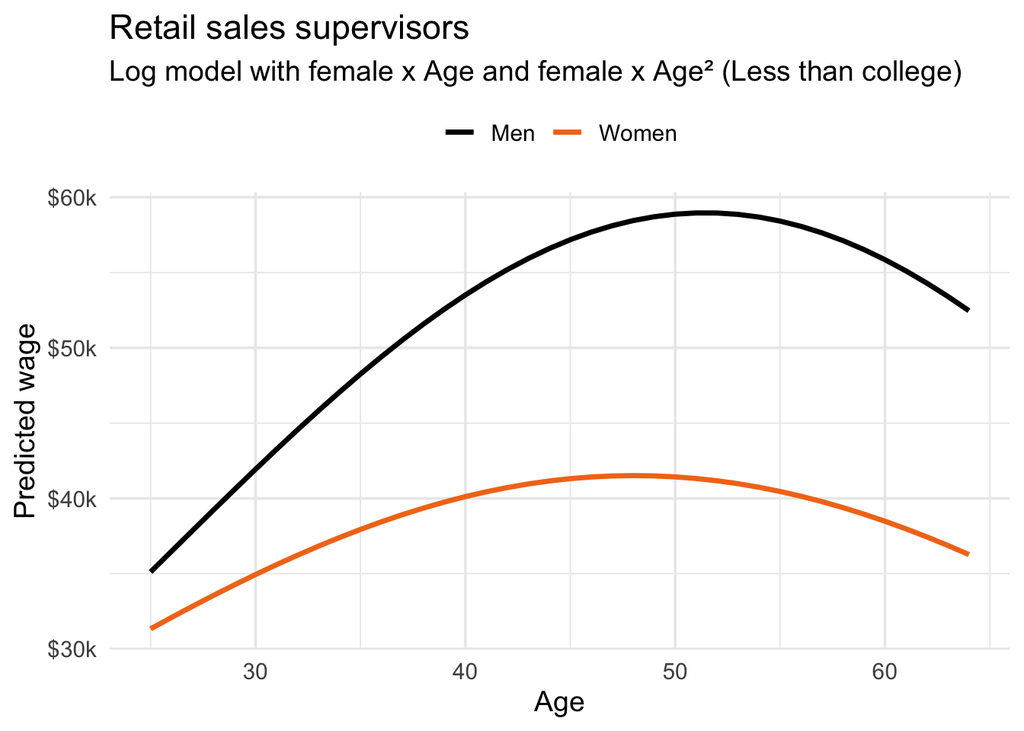

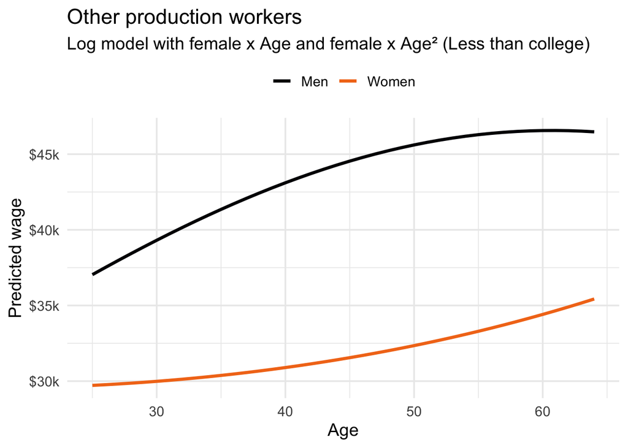

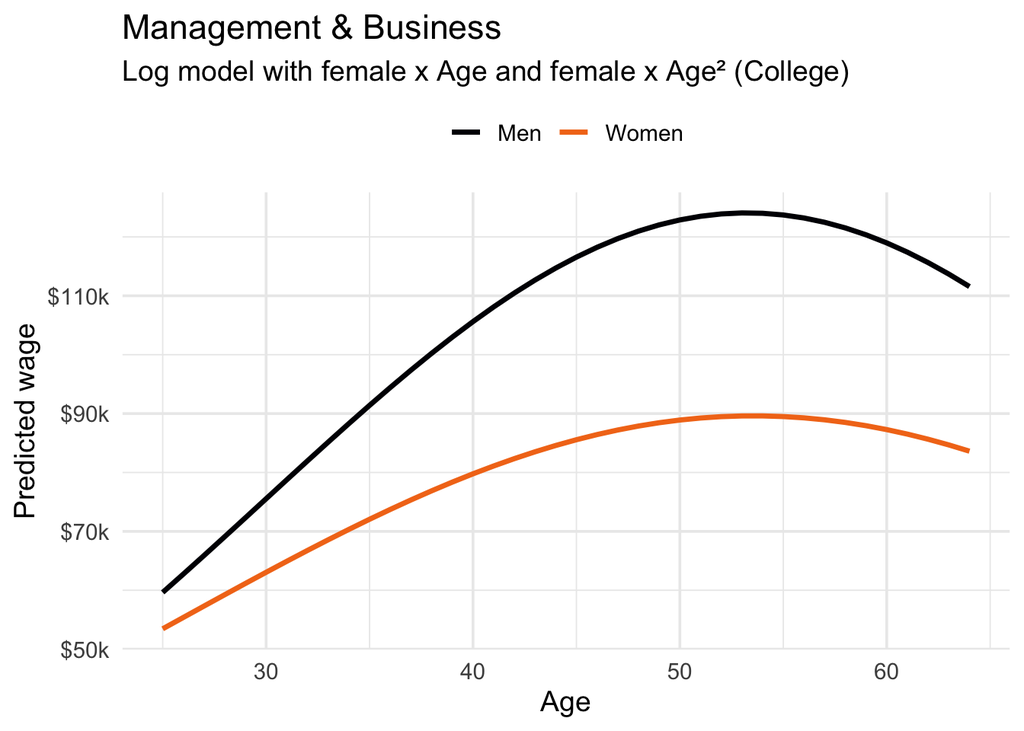

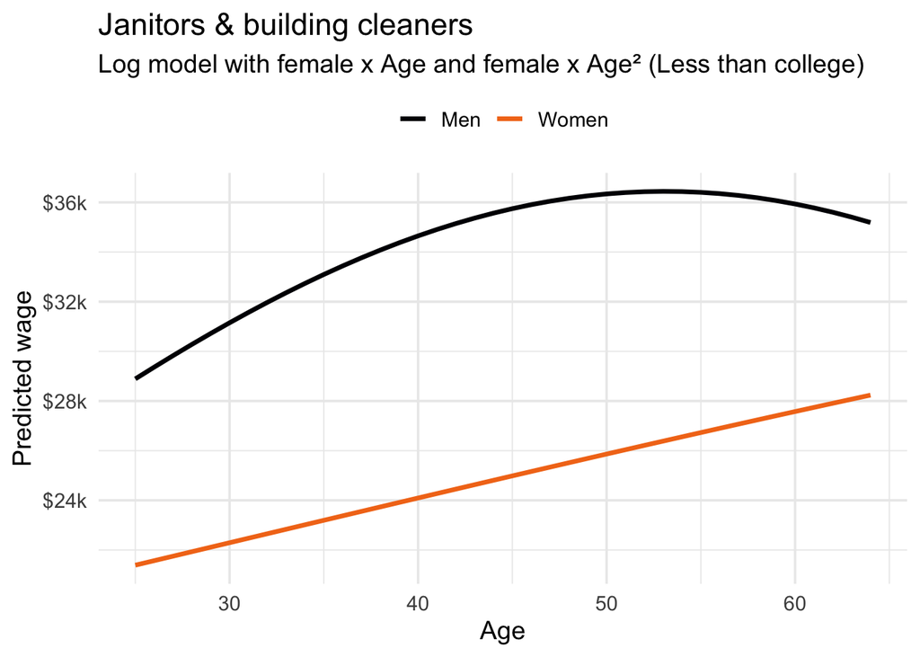

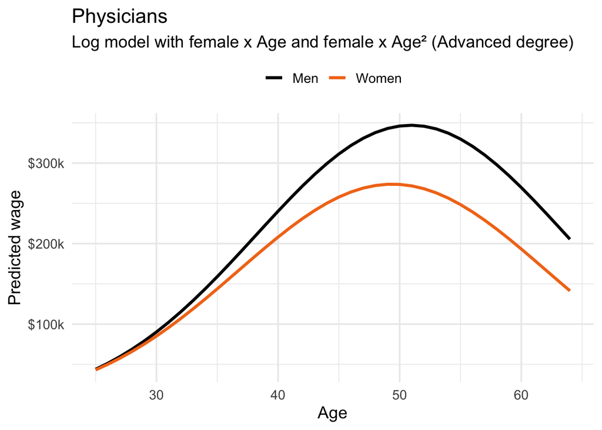

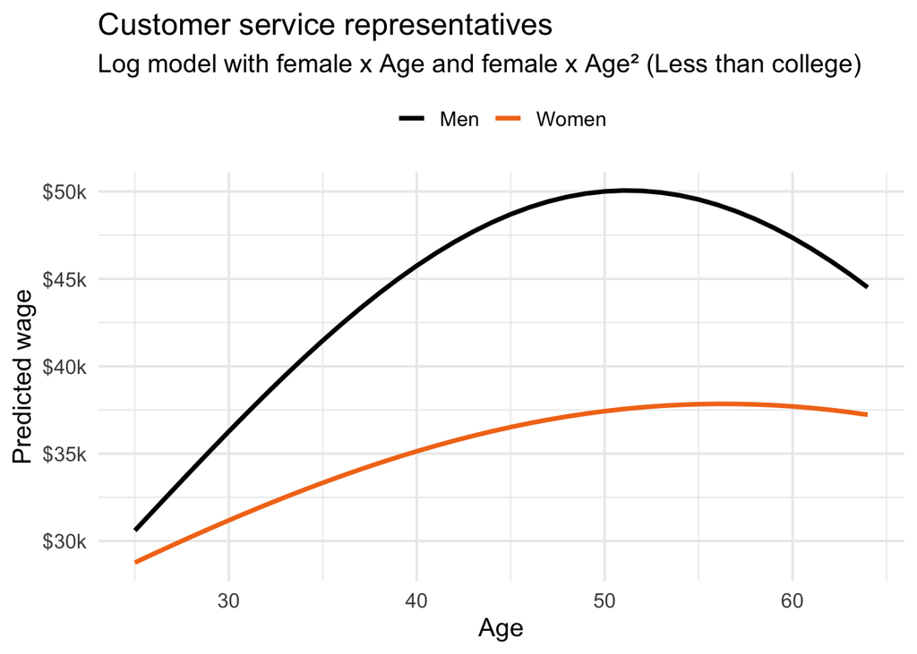

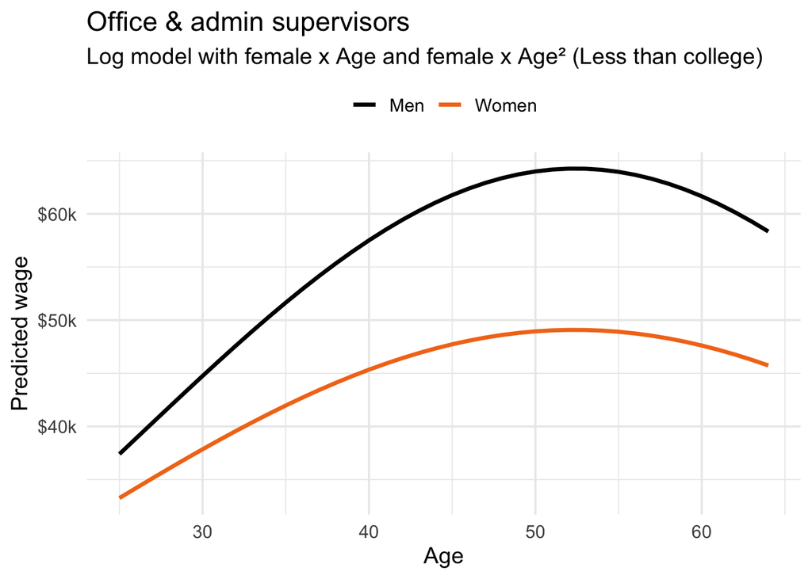

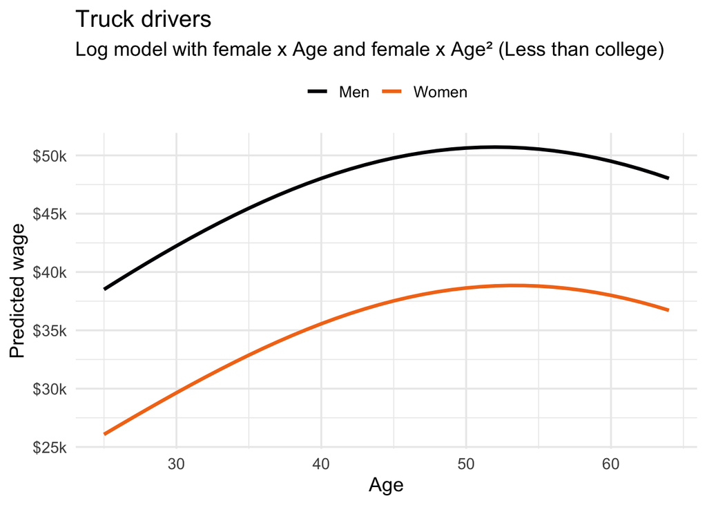

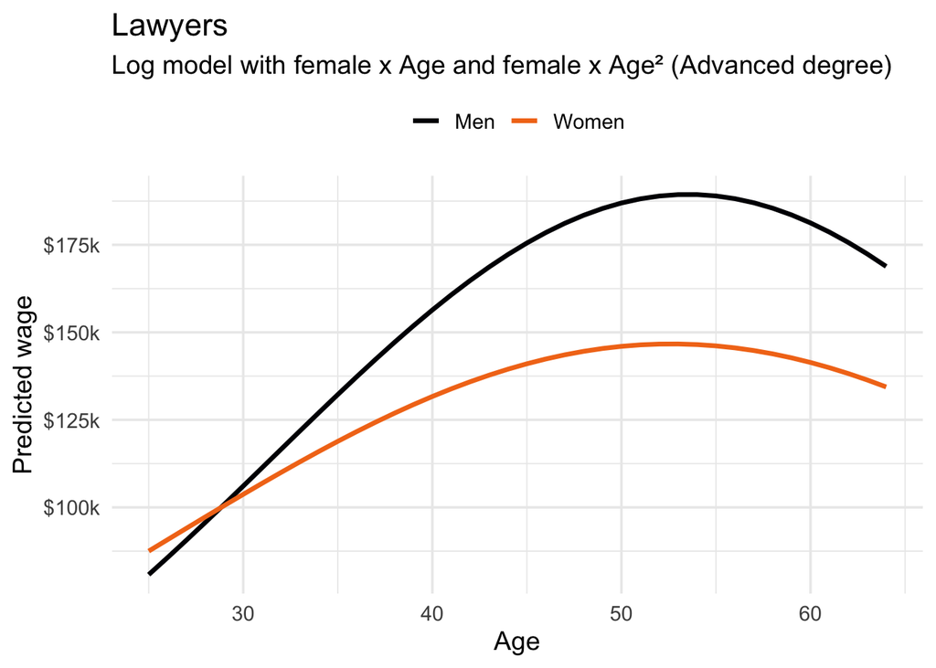

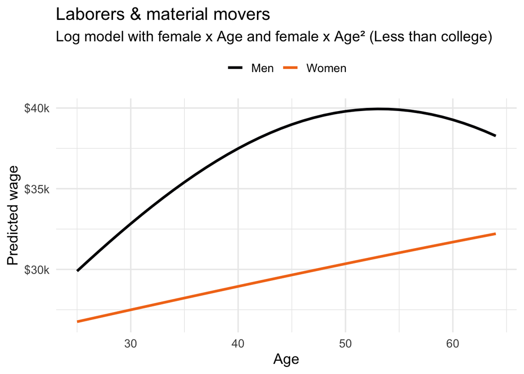

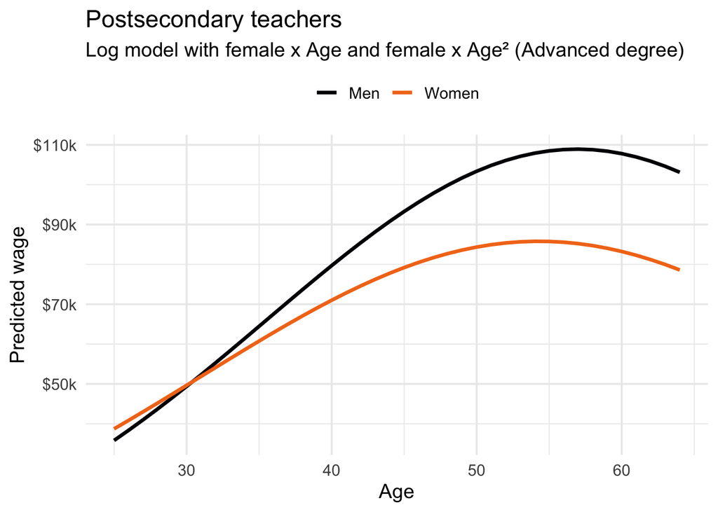

[9 more figures not shown]

```r
plot_int <- function(which_prof) {
  d <- filter(pred_all, profession == which_prof)
  ggplot(d, aes(x = AGE, y = pred, color = sex)) +
    geom_line(linewidth = 1.2) +
    scale_color_viridis_d(option = "inferno", end = 0.7) +
    scale_y_continuous(labels = scales::label_dollar(scale = 1/1000, suffix = "k")) +
    labs(x = "Age", y = "Predicted wage", color = NULL, title = which_prof,
         subtitle = paste0("Log model with female x Age and female x Age² (", d$educ_used[1], ")")) +
    theme_minimal(base_size = 14) + theme(legend.position = "top")
}

for (p in ratios$profession) {
  print(plot_int(p))
}
```

## Predicted values

Using this final model, we can look at some predicted values.

```r
# Fit the log wage model with gender-age interactions within one profession,
# then predict for a man and a woman at ages 28 and 50
predict_cases <- function(which_prof, educ) {
  m <- lm(log(INCWAGE) ~ AGE + I(AGE^2) + female + I(female * AGE) + I(female * AGE^2) +
            educ_college + educ_advdeg,
          data = filter(acs_work, profession == which_prof))
  newdata <- expand.grid(AGE = c(28, 50), female = c(0, 1))
  newdata$educ_college <- as.numeric(educ == "College")
  newdata$educ_advdeg  <- as.numeric(educ == "Advanced degree")
  newdata$pred <- exp(predict(m, newdata))
  newdata %>%
    mutate(sex = ifelse(female == 1, "Women", "Men")) %>%
    select(AGE, sex, pred) %>%
    pivot_wider(names_from = sex, values_from = pred) %>%
    mutate(profession = which_prof, education = educ,
           gap = Men - Women, ratio = Women / Men) %>%
    select(profession, education, AGE, Men, Women, gap, ratio)
}

cases <- bind_rows(
  predict_cases("Postsecondary teachers",       "Advanced degree"),
  predict_cases("Lawyers",                      "Advanced degree"),
  predict_cases("Secondary school teachers",    "Advanced degree"),
  predict_cases("Janitors & building cleaners", "Less than college"))

kable(cases, digits = 2, format.args = list(big.mark = ","),
      caption = "Predicted wages from the log wage model with gender-age interactions")
```

Predicted wages from the log wage model with gender-age interactions

| profession | education | AGE | Men | Women | gap | ratio |
| --- | --- | --- | --- | --- | --- | --- |
| Postsecondary teachers | Advanced degree | 28 | 43,707.10 | 45,192.61 | -1,485.51 | 1.03 |
| Postsecondary teachers | Advanced degree | 50 | 103,375.66 | 84,343.73 | 19,031.94 | 0.82 |
| Lawyers | Advanced degree | 28 | 95,737.47 | 97,298.32 | -1,560.85 | 1.02 |
| Lawyers | Advanced degree | 50 | 186,955.59 | 146,004.77 | 40,950.82 | 0.78 |
| Secondary school teachers | Advanced degree | 28 | 54,730.47 | 53,075.13 | 1,655.35 | 0.97 |
| Secondary school teachers | Advanced degree | 50 | 75,709.16 | 67,846.67 | 7,862.49 | 0.90 |
| Janitors & building cleaners | Less than college | 28 | 30,279.68 | 21,930.42 | 8,349.26 | 0.72 |
| Janitors & building cleaners | Less than college | 50 | 36,341.34 | 25,863.57 | 10,477.77 | 0.71 |

```r
# Sanity check: actual median wages for the same groups (ages 26-30 and 48-52)
acs_work %>%
  filter(profession %in% unique(cases$profession),
         AGE %in% 26:30 | AGE %in% 48:52) %>%
  mutate(age_group = ifelse(AGE <= 30, "26-30", "48-52")) %>%
  group_by(profession, age_group, sex) %>%
  summarize(median_wage = median(INCWAGE), n = n(), .groups = "drop") %>%
  pivot_wider(names_from = sex, values_from = c(median_wage, n)) %>%
  kable(format.args = list(big.mark = ","))
```

| profession | age_group | median_wage_Men | median_wage_Women | n_Men | n_Women |
| --- | --- | --- | --- | --- | --- |
| Janitors & building cleaners | 26-30 | 32,000 | 23,000 | 626 | 190 |
| Janitors & building cleaners | 48-52 | 38,000 | 27,000 | 977 | 476 |
| Lawyers | 26-30 | 81,000 | 85,000 | 323 | 371 |
| Lawyers | 48-52 | 173,000 | 140,000 | 727 | 525 |
| Postsecondary teachers | 26-30 | 34,000 | 36,000 | 409 | 410 |
| Postsecondary teachers | 48-52 | 90,000 | 80,000 | 603 | 617 |
| Secondary school teachers | 26-30 | 49,000 | 50,000 | 453 | 636 |
| Secondary school teachers | 48-52 | 70,000 | 64,000 | 644 | 836 |

## Discussion

**Is there a plausible causal link from X to Y?** For age and sex, the direction is clear: earning more cannot change your age or sex. But that does not mean the female coefficient measures discrimination alone. It also captures differences we do not observe, such as hours worked beyond 35 per week, job tasks within an occupation, employer, and time out of the labor force. Some of those differences may themselves result from discrimination or social expectations. For education the direction is less clean: people with more ability or ambition may be more likely to get degrees *and* to earn more, so the education coefficients probably overstate the true effect of schooling. For children, the link could run both ways: higher-earning men may be more likely to have children, and women on demanding career tracks may delay them. Finally, the sample includes only full-time, full-year workers. Women who cut back hours or left work after having children are not in it, so the gaps reported here probably understate the full gap in earnings.

**A single cross-section.** All results come from one year of data (2021). When I compare a 28-year-old with a 50-year-old, I am comparing two different people from two different generations, not the same person at two points in her career. The 50-year-old woman started her career around 1995, under different conditions, norms and laws than the 28-year-old, who started around 2015. So part of what looks like “the gap opening with age” may be a **generational (cohort) effect**: older women may have faced a larger gap all along, while younger women may face a smaller one that does not widen as much as they age.

It would be very interesting to repeat this analysis with the same data from 20 and 40 years ago (for example, the 2000 and 1980 Census samples). That would show whether today’s 50-year-old women already had a gap at age 28, and whether the gap for young workers has been shrinking over time.

**Is the gap disappearing?** Much has been made of the gender wage gap, and these results suggest it is disappearing for some groups but not others. Among young, highly educated professionals, it has largely closed: at age 28, female lawyers and college professors earn as much as or slightly more than men in the same jobs, and young teachers and nurses earn close to the same. But a gap still opens over the course of professional careers, especially in law, medicine, management and sales, in the years when most workers have young children. Mothers earn about the same as women without children, while fathers earn 10–30% more than men without children. In lower-wage manual and service jobs, such as janitors, truck drivers and production workers, women earn 20–30% less than men from the very start, and that gap remains fairly constant. So the progress appears concentrated among young, college-educated women, while the gap remains for women in lower-wage jobs and for women in professional careers once family responsibilities begin.